# McDonald's Menu Nutritional Analysis - Project

### C. Identify trends and patterns in the dataset.

In this step, we will examine how different nutritional variables across the items correlate with each other by visualizing the correlations using pair plots and heatmaps.

```python
nutritional_vars = ['Calories','Total Fat', 'Cholesterol','Carbohydrates','Proteins']
nutritional_vars
```

```
['Calories', 'Total Fat', 'Cholesterol', 'Carbohydrates', 'Proteins']
```

```python
calories_vs_nutrients = df[['Calories','Total Fat', 'Cholesterol','Carbohydrates','Protein']].corr()
print(calories_vs_nutrients)
```

```
               Calories  Total Fat  Cholesterol  Carbohydrates   Protein
Calories       1.000000   0.904409     0.596399       0.781539  0.787847
Total Fat      0.904409   1.000000     0.680547       0.461213  0.807773
Cholesterol    0.596399   0.680547     1.000000       0.270977  0.561561
Carbohydrates  0.781539   0.461213     0.270977       1.000000  0.352122
Protein        0.787847   0.807773     0.561561       0.352122  1.000000
```

The above code provides a numerical matrix showing how the other nutrients correlate with calories, but it doesn't give us a clear visual understanding. Therefore, we will rely on visualizing the correlation matrix and plot the correlations for better insight.

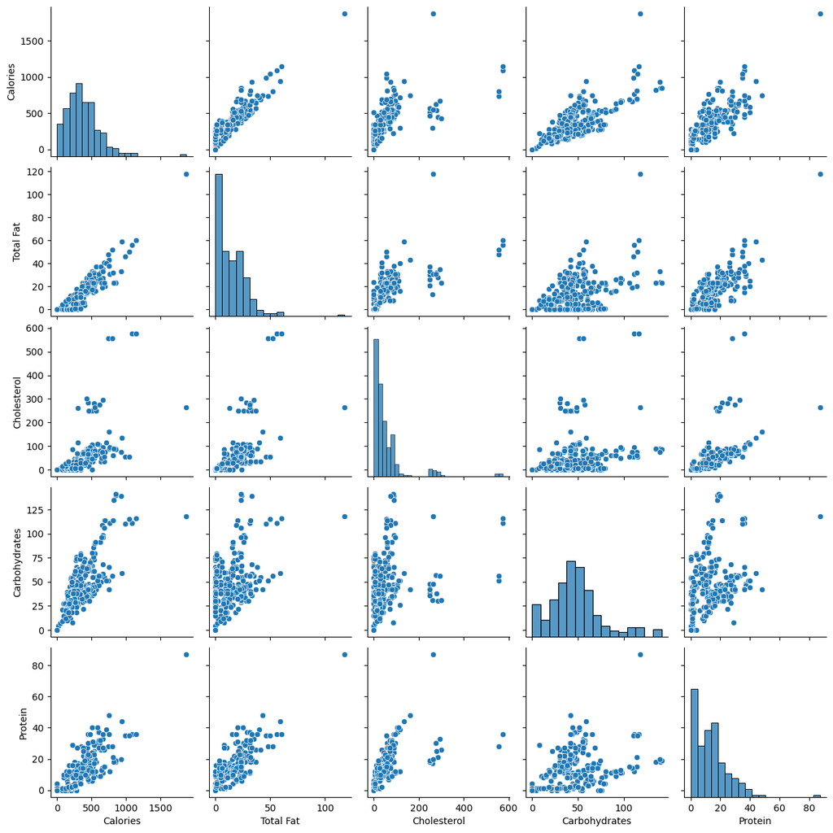

```python
sns.pairplot(df[['Calories','Total Fat', 'Cholesterol','Carbohydrates','Protein']])
```

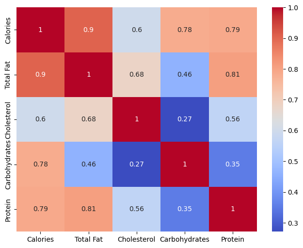

```python
plt.figure(figsize=(8,6))
sns.heatmap(calories_vs_nutrients, annot=True, cmap='coolwarm')  # 'coolwarm' for a vibrant and contrasting color map
plt.show()
```

The analysis reveals the following trends and patterns:

- **Calories and Total Fat:** There is a strong positive correlation (0.904) between calorie count and total fat content, suggesting that menu items with higher calorie counts tend to have higher total fat.
- **Total Fat and Protein:** The correlation between total fat and protein is also high (0.807), indicating that items rich in protein are likely to contain more total fat.
- **Calories and Protein:** The positive correlation (0.787) between calories and protein suggests that menu items with more calories generally contain more protein.
- **Calories and Carbohydrates:** A positive correlation (0.781) between calories and carbohydrates indicates that items with higher calorie counts tend to have higher carbohydrate values.

To summarize the correlation matrix, I have included a heatmap that visually represents the relationships between these nutrients in a simpler manner.